# BCH369 - Introduction to Biochemistry

ArunK

[🌲](https://arun-krishnaraj.github.io/evergreen)

### Notes

#### Week 1 Lectures

Intro Video 1

- Chemistry: study of matter and changes in matter (chemical or physical)
- focus on understanding the link between structure and function
- macromolecules: protein, polysaccharide, nucleic acids, lipids

| Macromolecule | Monomer | Linkage |
| --- | --- | --- |
| Nucleic Acid | Nucleotides | Phosphodiester |
| Protein | Amino Acid | Peptide (amide) |
| Polysaccharide | Monosaccharide | Glycoside (ether) |
| Lipids | Fatty Acids | Ester |

Clutch Functional Groups

- functional groups tend to be reactive and extend off carbon backbone; linkages used to link different kinds of molecules
- amino acids have amino and carboxyl groups
- carbohydrates have many hydroxyl groups, and ether linkages
- fatty acids typically have methyl groups
- nucleotides have phosphodiester linkages
- most useful for life are CHNOPS; trace elements are also required for life

Water Video 2

- weak bonds permit dynamic interactions; Brownian motion initiates biochemical interactions
- IMF’s arise from electrostatic interactions
  - energy is given by $E = \frac{kq_1q_2}{Dr}$, where k is a scaling constant, $q_i$ are charges, $D$ is the dielectric constant, and $r$ is distance
    - dielectric constant varies based on the medium (weaker interactions in water)
- Hydrogen bonds including Nitrogen and Oxygen
  - Hydrogen bonds are weaker (and longer distance) and can be disrupted by water
- Hydrophobic effect: spontaneous self association of nonpolar molecules in aqueous solutions

Clutch water

- H$_2$O: polar molecule, 2 polar covalent bonds; bent with 2 lone pairs
  - able to form up to 4 hydrogen bonds
    - -> high boiling/melting point, heat capacity, heat of vaporization, high surface tension
      - cohesion: intermolecular interactions
      - adhesion: interaction with other non-water objects
- solubility: ability of solute to dissolve in solvent
  - water interacts with polar substances, dissolves electrolytes
    - electrolytes dissociate to form ions in H$_2$O
    - hydrated electrolytes have a hydration shell of H$_2$O molecules
    - dielectric constant: ability of solvent to dissolve, diminish electrostatic interactions
- water has similar weight, higher boiling/melting points, heat capacity, dielectric constant than methane; lower density as a solid

Clutch IMF

- Intra vs inter molecular bonds for within or between molecules
- ionic bond: opposite charge due to gain/loss of electrons
- covalent bonds: two atoms share a pair of electrons, equally or unequally based on electronegativity (polar or nonpolar)
- H bonds: involve H and an electronegative atom
- Dipole: shift in electron density due to electronegativity differences (dipole-dipole)
- Van der Waals created by instantaneous dipoles

Clutch Hydrophobic

- exclusion of hydrophobic substances by water (insoluble, form a separate phase)
  - hydrophobic nonpolar substances have weak affinity for each other
    - creation of hydration shells:
      - 1. cannot participate in H bonding (normally)
      - 2. move slower; fewer, higher energy H bonds
      - 3. more ordered, lower entropy
    - -> it becomes thermodynamically favorable for hydration shells to merge (clumping reduces entropy, but offset by increased free H$_2$O entropy)
- use of nonpolar R-groups in aqueous solution mediates folding (lower local entropy)
  - phospholipids are put into a lower entropy state as nonpolar tails clump

pH & buffers video 2

- pH: measure of concentration of [H$_3$O$^+$] in aqueous solution; pH = -log[H$_3$O$^+$]
  $$H_2O + H_2O \leftrightarrow OH^- + H_3O^+$$
  (auto ionization)
  $$K_w= [H_3O^+][OH^-] = 1*10^{-14}$$
- weak acids create H$_3$O$^+$ and anion (mostly remain), shifts equilibrium
- cells utilize buffers to regulate pH (conjugate acid/base partners)
  - acid: proton donor; base: proton acceptor
- other cellular molecules can act like weak acids; change pH without buffer

$$K_a = \frac{[A^-][H_3O^+]}{[HA]}$$
$$pKa = -log(Ka)$$
- when large amounts of acid and anion are present, can use the Henderson Hesselbach equation
$$pH = pKa + log\frac{[OA_c^-]}{[HOA_c]}$$
- when $[A^-] = [HA]$, then $pH=pKa$ - when $pH>pKa$, $[A^-]$ predominates; $pH<pKa$, $[HA]$ predominates

Clutch pH

- $pH = -log[H^+] = log\frac{1}{[H^+]}$, measures proton concentration (indirectly measures [OH$^-$]); $K_W = [OH^-][H^+]$
- pH ranges from 0 to 14, neutral of 7, basic greater, acidic lower
  - base: [H$^+$] < [OH$^-$]
  - acid: [H$^+$] > [OH$^-$]

Clutch $K_a$

-$K_a$: acid dissociation constant, associated with hydrogen donors (acids), $K_{eq}$ for acid’s dissociation; linear, positive measure of acid strength (ion constant)
$$HA \text{ (conjugate acid)} \rightarrow H^+ + A^- \text{ (conjugate base)}$$
- polyprotic acid: multiple acidic H atoms that can dissociate, each has its own $K_a$

- use ICE table to find [H$^+$] for pKa (equilibrium concentrations for pKa)
- $pKa = -log(Ka)$, higher pKa is a weaker acid

Clutch Henderson Hasselbach

- strong acids have small pKa, tend to completely dissociate ([HCl]=[H$^+$]$_f$)
- weak acids have high pKa, do not completely dissociate (most biological acids are weak acids)
- HH equation used for finding final pH or conjugate base: conjugate acid ratio for weaker acids
  $$pH = pKa + log \frac{\text{[conjugate base]}_f}{\text{[conjugate acid]}_f}$$

Clutch predominant species

- conjugate base and acid are different forms of a molecule; pH of solution and pKa of acid determines the predominant species

| Compare.pH.to.pKa | Predominant.Species | Protonated. | HH.equation |
| --- | --- | --- | --- |
| pH = pKa | CB = CA | 50% 50% | pH = pKa +log(1) |
| pH < pKa | CB < CA | mostly protonated | pH = pKa +log(<1) |
| pH > pKa | CB > CA | mostly deprotonated | pH = pKa +log(>1) |

Clutch titrations

- titration: measure pH changes of acid/base solutions to determine pKa values
  - solution of known concentration (titrant) added to solution of unknown concentration (analyte) until neutralization is reached (shown by color change)
  - determines concentration of acid/base in solution; pKa of a weak acid
- titration curve: analyte pH on y-axis, titrant added on x-axis
  - equivalence point: point when mols analyte = mols titrant (always at pH = 7 for strong acid/strong base titration)
- inflection point: when half of acid is neutralized (pH = pKa for weak acids)
  - -> pH = pKa, [CB] = [CA]
- titration curves for polyprotic acids have multiple inflection and equivalence points, each indicating the pKa of a H$^+$

Clutch Buffers

- buffers: resist changes in pH, small amounts of strong acid/base
  - can be prepared with the Henderson-Hasselbach equation
- weak acids/bases + conjugates are the most effective buffers, centered around $\pm1$ of the pKa and inflection point
- biological buffers use weak acids, can be inter or intra cellular buffer systems
  - intracellular pH $\approx$ 7, intercellular pH $\approx$ 7.4

1.1 Living Systems Require a limited variety of atoms and molecules

- C, H, O contribute 98% of organic atoms
- carbon’s 4 bond ability and high bond strength make it crucial for organic chemistry

1.2 4 classes of Biomolecules

- proteins: constructed from 20 amino acids, linked with peptide bonds; serve a number of biochemical functions: receptors, signals, structure, catalysts
- nucleic acids: store/transfer biological information; 4 nucleotides linked by phosphodiester bonds; DNA vs RNA (deoxyribose vs ribose sugar, 2 strand vs 1 strand, T vs U base); mRNA, tRNA used for cellular manufacturing
- lipids: lower molecular weight, not polymers of repeat units; usually part hydrophilic/phobic; contributes to membrane structures and energy storage
- carbohydrates: fuel sources; can be highly linked/branched, play roles in cell recognition

1.3 Central dogma of Biological Information Transfer

- selective expression determines ultimate cellular function
  - translation: conversion of DNA to mRNA transcript; translation then creates a useable form from mRNA code

1.4 Cellular membranes

- cells are differentiated by membrane bilayers; hydrophilic heads interact with the environment, while hydrophobic tails interact with each other
  - eukaryotic cells are characterized by their membrane-enclosed compartments
- barrier function of the plasma membrane is able to be rendered semipermeable
- cytoplasm: organized network of cytoskeleton network fibers, site of a number of processes
- cell wall: constructed of cellulose, linear glucose polymer
- nucleus: double membrane bound house of the genome, pores allow selective transportation
- mitochrondria: outer and inner (invaginated) membranes, energy generation
- chloroplast: site of photosynthesis, double membrane bound organelle
- endoplasmic reticulum: has exterior surface and interior lumens; smooth and rough ER; smooth: exogenous chemical processing; rough: attached ribosomes synthesize proteins for insertion into cellular membranes or secreted
- Golgi complex: post rough ER protein processing and sorting
- secretory granule: vesicle intended for secretion buds off of Golgi Complex, eventually fuses with cellular membrane, releasing cargo
  - endocytosis involves cell membrane invaginating and budding (can be phagocytosis depending on bud size)
  - lysosomes: sent to fuse with endosomes and digest the material
  - vacuoles: plant organelle holding water, ions, nutrients

2.1 Thermal motions

- thermal noise resulting in Brownian motion of particles, which facilitates interactions

2.2 Aqueous Solutions

- water mobilizes molecules, permits Brownian motion
  - hydrogen bonds: intermolecular bonding resulting from $\delta^+$ on H and $\delta^-$ on another atom
  - nonpolar (hydrophobic molecules) can’t dissolve in water

2.3 Weak interactions

- ionic bonds occur between ions; water weakens ionic bonds by creating hydration shells
- Hydrogen bonds occur when H is covalently bonded to an electronegative atom
  - water disrupts existing H bonds by forming new ones
- Van der Waals: random partial charges can interact (results of transient assymetry)

2.4 Hydrophobic molecules

- nonpolar molecules are clustered (decreased entropy, which frees more H$_2$O molecules, overall increasing entropy)
- amphipathic/philic: distinct chemical properties in a molecule

2.5 pH

- slight alterations in pH can impact electrostatic environment, and change bonding behaviors

#### Week 2 Lectures

Protonated vs Deprotonated Video 2

- biochemical systems exist in aqueous environment, weak acids and buffer systems contribute to pH changes
- amino acid groups become protonated or deprotonated dominant based on their equilibrium constants
- zwitterionic form: amino group has a positive charge, carboxylic group is negatively charged; net charge is neutral
- R functional groups can move from protonated to deprotonated based on pH; proteins are protonated at low pH, deprotonated at high pH and pick up an overall negative charge
  - isoelectric point: point where number of protonated and deprotonated R groups is equal and molecular charge is 0 (pH = pI)
- ampholytes contain both acidic and basic pK$_a$ values (includes many biologically relevant molecules)
- for a simple molecule, the isoelectric point is the average of the two pK$_a$ values surrounding the isoelectric species

Protein Structure Video 3

- peptide bond formation through condensation reaction, carboxylic-amine functional group linkage
- primary structure (I$^o$): sequence and direction of amino acids, written in amino terminal to carboxyl terminal end; amino acids referred to as residues
  - peptide bonds are planar (no free rotation); caused by peptide resonance, which gives double bond character
  - $\alpha$ carbon bonds do have free rotation: N-C$_\alpha$ ($\Phi$) and C$_\alpha$-carbonyl ($\Psi$) bonds
    - the rotation of the $\Phi$ and $\Psi$ bonds (torsion angle) determines the path of polypeptide chain
- secondary structure (II$^o$): stabilized by backbone H-bonding
  - alpha helix bonding scheme stabilized by hydrogen bonding between amine group hydrogen and carbonyl group oxygen (4 amino acids down, formation of the right helix)
  - beta sheet stabilized by hydrogen bonding between amine hydrogen and carbonyl oxygen; parallel or antiparallel based on direction of peptides (amine terminal to carbon terminal)
  - reverse turns allow protein compaction; consist of carbonyl oxygen binding to amine group hydrogen
- categories of proteins:
  - fibrous: long extensions of secondary structure (don’t use higher structures); includes collagen proteins, triple superhelical cables that contribute structural support
  - globular: tend to be water soluble, separation of hydrophobic/philic regions; highly compact
  - membrane
- tertiary structure (III$^o$): involves how the protein folds on itself, stabilized by IMF between R groups
  - motif: supersecondary structures; combinations of secondary structures found in many proteins
  - domains: two or more identical structures found in proteins
- quaternary structure: only exists when multiple polypeptide chains are assembled into a single protein; composed of any number of subunits (like $\alpha_2 \beta_2$ tetramer of human hemoglobin)
- folding funnel: maximum entropy and minimum structure moves to low entropy and native structure state
- Intrinsically disordered proteins (IDPs) do not have a defined structure (under physiological conditions) until they interact with other molecules

Protein Purification Video 4

- proteome: functional representation of the genome
- proteins can be purified based on chemical or physical properties

3.1 Proteins are built from 20 amino acids

- $\alpha$ amino acids consist of a central carbon, amino group, carboxylic group, and R groups
  - $\alpha$ aminos are chiral (L and D isomers, only L amino acids are used in proteins)
- free amino acids at neutral pH exist primarily as dipolar ions (zwitterions); the amino group is usually protonated (NH$^+_3$) and the carboxyl group is deprotonated (COO$^-$)

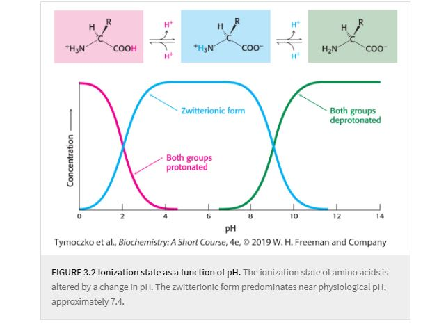

3.2 Amino acids contain a wide array of functional groups

- 20 kinds of side chain change the character of aminos (sometimes conferred by functional groups); can be classified by R groups
  - Hydrophobic amino acids (nonpolar R groups); can usually pack closely together due to hydrophobic effect
    - side chains consisting of hydrogen and carbon only are hydrophobic (glycine, alanine)
    - aliphatic side chains are found in valine, leucine, isoleucine, methionine, proline (conformationally restrictive)
    - aromatic side chains (phenylalanine, tryptophan)

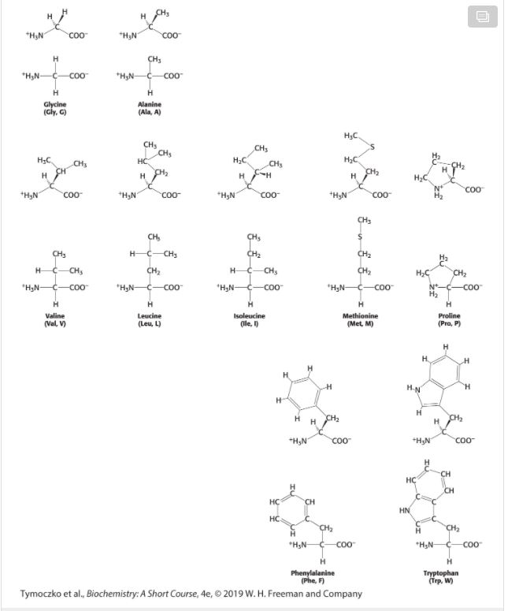

  - Polar amino acids (neutral overall, R groups with uneven charge due to electronegative atoms in the R group)
    - serine, threonine, tyrosine contain hydroxyl groups ($\delta^-$ on oxygen); makes these more reactive than nonpolar counterparts alanine, valine, phenylalanine
    - Cysteine contains a thiol (-SH) group instead of hydroxyl (more reactive than -OH)
    - asparagine, glutamine both contain terminal carboxamide

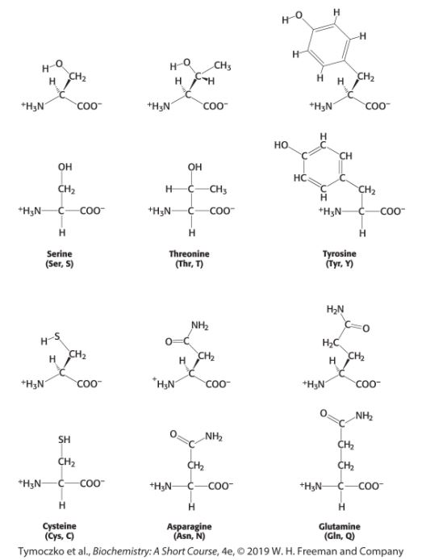

  - Positively charged amino acids (R groups hold positive charge at pH $\approx$ 7.4), highly hydrophilic
    - Lysine, arginine: long side chains with positive charge groups
    - histidine: aromatic ring with positive charge (can be uncharged or charged near neutral pH)

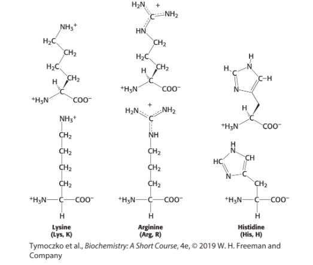

  - Negatively charged amino acids (R groups hold negative charge at ph $\approx$ 7.4)
  - acidic side chains are negatively charged: aspartic acid, glutamic acid

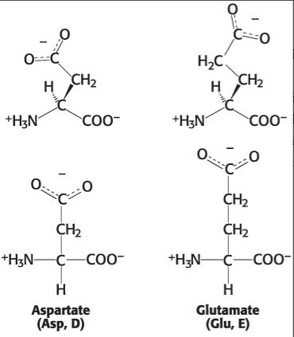

- tyrosine, cysteine, arginine, lysine, histidine, aspartic and glutamic acids can form ionic bonds or donate/accept protons (acid-base catalysis)

3.3 Essential amino acids

- some aminos can’t be synthesized by humans

4.1 Primary structure

- protein 3d structure depends primarily on primary structure: linear polymers formed by sequence of amino acids (peptide or amide bond formation)
  - polypeptides have polarity ($\alpha$ amino (N-terminal) and $\alpha$ carboxyl (C-terminal) groups)
  - consists of a backbone (repeat carbonyl, amino groups) and unique side chains
- protein amino acid sequences are uniquely specified by genes, determine structure and function; alterations can result in disease, capture evolutionary history
  - peptide bonds are planar, due to double-bond character from resonance structures
    - both the trans and cis configuration are possible (but almost all are trans)

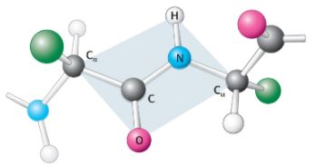

    - bonds between $\alpha$-carbon and amino and carbonyl groups are pure single bonds, can rotate freely (not all combinations are possible)

4.2 Secondary structure

- regularly folded segments are considered secondary structure
- Alpha helix: rodlike structure with tightly coiled backbone, side chains extend outward; CO groups form hydrogen bonds with NH groupps that are four residues ahead
  - tend to be right-handed due to steric clashes
  - not all aminos are stable in an $\alpha$ helix
- Beta sheets: composed of multiple $\beta$ strand that link through hydrogen bonds (can be parallel or antiparallel based on polypeptide polarity)
  - sheets can be non-adjacent sections; can also be mixed, pure parallel or antiparallel sheets
  - usually depicted as flat arrows pointing towards the C-terminal end
- reverse turns and loops: common structural elements, increase compaction
- fibrous proteins: simple 3d structure, mostly derived from secondary structure
  - $\alpha$-Keratin contains two right handed alpha helices that form a left handed superhelix (coiled-coil protein)
  - collagen has 3 helical chains, each stabilized by steric repulsion instead of hydrogen bonds
    - formation of a triple stranded superhelical cable

4.3 Tertiary structure

- refers to spatial arrangement arising from interactions between R groups
- motifs (supersecondary structures): combinations of secondary structure commonly found
  - domains are similarly folding units on a single polypeptide

4.4 Quaternary structure

- refers to the arrangement of polypeptide subunits interacting to form a single functional protein
  - dimers consist of two identical subunits: Cro found in $\lambda$ virus regulates gene expression
  - vary in complexity; human hemoglobin $\alpha_2\beta_2$ tetramers

4.5 Amino acid sequence determines 3d structure

- randomly coiled polypeptides have no enyzymatic activity (denatured)
  - denatured polypeptides spontaneously refold into a catalytically avtice form when denaturing agents are removed; information specifying catalytically active configuration is contained in the amino sequence itself (native structure is most thermodynamically stable)
    - some proteins require special conditions or chaperone proteins to reestablish native configurations
  - Levinthal’s paradox: large difference between calculated and actual protein folding times
    - cumulative selection: partly correct intermediates are retained in future search steps
    - folding funnel is used to visualize a decreasing entropy state moving towards native configuration
- some proteins can exist in multiple conformations
  - intrinsically disordered proteins (IDPs), no discrete structure; assume a defined structure when interacting with other proteins (can take on different biochemical functions)
  - metamorphic proteins: exist in multiple forms at equilibrium; interactions with other molecules create unique functional complexes (mutually exclusive biochemical activities)

5.1 The proteome

- encompasses functional information; interactions, types, functions of encoded proteins; doesn’t exist in isolation since proteins can interact to change function

5.2 Purification of proteins

- assays can be used to identify if purification is working (uses unique identifier of the protein)
  - specific activity: ratio of enzyme activity to amount of protein present at each step
- homogenate: mixture of cellular components created after cell membrane disruption; homogenate is centrifuged and enriched in an organelle, repeating with higher force (differential centrifugation)
  - salting out: most proteins precipitate out of solution at high salinity (salts compete with proteins for solvent); dialysis is required to remove salt and restore protein activity
  - molecular exclusion chromatography (gel-filtration chromatography): separation based on size, carbohydrate beads capture slow molecules; largest molecules exit filtration column first
  - ion-exchange chromatography: separation by net charge using ion exhchange beads, then increasing salt in buffer to release proteins bound to beads
  - affinity chromatography: uses protein specific chemical affinity
  - high-pressure liquid chromatography (HPLC): enhances column techniques by using finer beads and pressurizing the column
- distance and speed a molecule move in gel depends on its net charge and size; protein electrophoresis is vertical, pH is adjusted so all proteins are negatively charged
  - small proteins move rapidly, and large proteins remain near application site; can be stained to identify most effective purification method (SDS-PAGE)
- isoelectric focusing: apply electrophoresis in a pH gradient, once the protein stops it has reached pI
  - can be combined with perpendicular SDS-PAGE in two dimensional electrophoresis; resolves many proteins at once with high precision
- purification evaluation:
  - total protein, total activity, specific activity, yield, purification level

5.3 Immunological purification

- ultracentrifuges can separate small molecular complexes; rate of movement depends on mass, density, and shape: sedimentation coefficient
  $$s=m(1-\bar{v}\rho)/f$$
  - the smaller the $s$ value, the slower a molecule moves in centrifuge
- gradient centrifugation can be used to assay protein movement; after the variable density tube is emptied, presence of protein can be determined by catalytic activity or other functional property
- antibodies are synthesized in response to foreign substances; specific and high affinity for their antigens
  - use antibody response to generate proteins after injecting antigens (centrifuge and isolation to produce antiserum); antibodies can be heterogeneous after isolation (polyclonal antibodies)
- monoclonal antibodies can be created from multiple myeloma cancer cells; a plasma cell divides uncontrollably into a large number of cells of a single kind
  - antibody tissue can be fused with a immortal myeloma cell; produces a specific monoclonal antibody
- antibodys can be pulled out of solution using their complementary binding molecule attached to insoluble beads
- enzyme-linked immunosorbent assay (ELISA): uses enzymes that create a newly colored product when exposed to substrate; this enzyme is linked to an antibody
  - if the antigen is present, it binds to the antibody-enzyme complex and frees the enzyme to generate color when substrate is added
- western blotting: after running sample on SDS gel, individual proteins can be blotted using a current; specific antibody is added to bind to the antigen of interest
  - a second antibody (either fluorescent or producing a colored product) that binds to the first is added

5.4 Primary structure determination

- learning the primary structure of a protein can tell us about the eventual structure and function
- peptides can be hydrolyzed, then separated and visualized using flourescent products; produces an unordered composition of amino acids
  - Edman degradation can be used to remove one reside at a time from the N terminus (PTH reacts to break off amino acids by cyclizing them)
    - cleavage is needed to create manageable polypeptides for sequencing; need to look at peptide overlap to reorder the segments
- Mass spectrometry: analyzes ionized forms of molecules in gas; measures acceleration by electric field to determine mass
  - Matrix-assisted laser desorption-ionization (MALDI): combine peptide of interest with a compound absorbant of laser light
    - multiple techniques need to be combined to deterine ultimate protein identity
    - protein sequence can be found using mass spectrometry by analyzing smaller peptide chains created by bombardment with inert gas
- amino acid sequence can provide information:
  - compared with prior sequences to identify functional similarities
  - can be used to establish evolutionary pathways based on individual sequence homologies
  - internal repeats can reveal history of protein creation
  - individual amino acids can signal protein destination or processing location
  - allows molecular understanding of diseases resulting from mutations
  - knowing protein structure can help understand functional gene regions

Lecture Video 1

- It’s important to remember the structure and function of amino acids in order to fully understand the function and behavior of proteins
- Space filling model is usually more accurate than the ribbon model
- All amino acids except one have a chiral center, only L isomers are found in proteins
- Amino acids can be separated into 4 groups based on the behavior of their R groups
  - Hydrophobic amino acids
  - Polar amino acids
  - Positively charged amino acids
  - Negatively charged amino acids
- Some amino acids are essential, meaning that humans are incapable of synthesizing them and require them from food

Clutch Amino Acid Groups - There are 20 standard amino acids, which differ by their R groups - grouped together based on characteristics of R groups at physiological pH - amino and carboxyl charge groups make backbones dipolar at physiological pH - Amino acids can be grouped by functional or structural groupings

Clutch Amino Acid configuration - almost all $\alpha$ amino acids are chiral (except glycine), biochemistry uses S and R notation vs L and D configuration - use chiral group priorities to figure out configurations (R group is always priority #3 except in Cys) - Standard Fisher Projection: - Carboxyl on top, longest carbon chain vertical, L-amino acid group is on the left - Non-standard Fisher Projection - determine R and S configuration of the $\alpha$ carbon, pick S configuration for all except L-Cys - L Amino acids can be represented as Fischer projections, Amine down/wedge, R group down/dashed, R group up/wedge

Clutch Zwitterions

- zwitterion: dipolar molecules with two groups of opposite charge (common protein backbone of free amino acids at physiological pH)
- $pK_a$ is a measure of acidic hydrogen strength
  - comparing individual $pK_a$ values to pH to determine predominant amino acid structure
  - $\alpha$ amino and carboxyl groups have $pK_a$ of 9-10.5 and 2

Clutch nonionizable R groups

- R groups that are uncharged (only 2 $pK_a$ values for backbone); 13 non-ionizable amino acids

Clutch isoelectric point

- pH when molecule have no net charge, always the midpoint between 2 $pK_a$ values involving the neutral species

Clutch isoelectric for ionizable R groups

- need to pick 2 of 3 $pK_a$ values to average; pick the two that surround the region that makes the molecule net neutral charge

Clutch peptide bonds

- amide covalent linkages between amino acids in a polypeptide chain; endergonic dehydration synthesis reactions
  - hydrolysis is the opposite, used for peptide bond cleavage

Clutch primary structure

- amino acid composition and sequence of amino acid residues in a chain (N to C terminal)
- primary structure determines shape, function (including all other levels of structure)

Clutch altering primary structure

- composition or sequence can be altered; slight amino acid changes can change shape and function (depends on property of replaced amino acid)

#### Week 3 Lectures

Enzymes Intro Video 1

- assay: test for the presence of protein activity; used to check for protein purity
  - used to measure how fast a chemical reaction occurs (rate of appearance of product or disappearance of a reactant)
  - specific activity depends on the protein: can be enzymatic, binding, or transport
- enzymes can sometimes catalyze both forward and reverse reactions; usually named descriptive to their impact on the substrate
  - catalysis occurs at the active site, usually substrate binding is enzyme specific
  - usually associated with a standard EC classification system, refers to the specific function and action of the enzyme
    - Oxidoreductases: transfer electrons between molecules; catalyze oxidation–reduction reactions
    - Transferases: transfer functional groups between molecules
    - Hydrolyases: cleaves molecules by the addition of water
    - Lyases: adds atoms or functional groups to a double bond or removes them to form double bonds
    - Isomerases: move functional groups within a molecule
    - Ligases: join two molecules in a reaction powered by ATP hydrolysis
  - some enzymes require cofactors for activity
    - coenzyme or metal ion: coenzymes can be prosthetic groups or cosubstrates depending on if they stay bound to the enzyme

Free Energy Video 2

- Free energy determines if a reaction is spontaneous; kinetics deals with how fast a change is
  - reaction are spontaneous if $\Delta G < 0$ (products have lower free energy than reactants, exergonic); non-spontaneous if $\Delta G > 0$ (products have a higher free energy than reactants, endergonic)
    - equilibrium favors the lower free energy state
    - some amount of activation energy is required to get reactants over the transition state
    - enzymes are able to change the activation energy of the transition state, speeding up the reaction process; enzymes cannot change the $\Delta G$ of a reaction
- lock and key model has the substrate and enzyme as unchanging pieces that fit together perfectly; induced fit included enzymatic structural changes when substrate enters
  - binding energy is released, lowering the level of activation energy required for formation of the transition state

Enzyme Kinematics Video 3

- we can use reaction speed measurements to learn more about the mechanism
  - rate law: relationship between reaction velocity and concentration of substrate, experimentally derived; many biochemical reactions have second-order rate equations
    - can be written as pseudo-first order rate laws if the reaction rate doesn’t change much based on the concentration of one of two substrates
  - initial velocities can be found by varying starting substrate concentration; max velocity is the limit on initial speed, limited by enzyme
- Michaelis-Menten Equation: explains hyperbolic velocity vs initial concentration to understand the mechanism of enzymes $V_o = \frac{Vmax[S]}{[S]+K_m}$
- review this

Enzyme Kinematics Video 4

- we can also solve for the point-slope form (Lineweaver-Burk plot) $\frac{1}{V_o}=\frac{K_m}{V_{max}}\frac{1}{[S]}+\frac{1}{V_{max}}$
- the best measure of catalytic efficiency is $\frac{k_{cat}}{K_M}$
  - diffusion imposed limit is $10^8-10^9$ (mol/L)$^{-1}$s$^{-1}$, these enzymes are perfect
- $k_m$ indicates the substrate concentration at which the reaction rate is half of the $V_{max}$
- $k_{cat}$ measures the rate of catalytic process
- sigmoidal rate curves signify allosteric enzymes; catalysts and information sensors, not just M-M enzymes
  - allosteric enzymes can be regulated by products of their pathways; pathway rate depends on something besides the enzyme
  - synthesis can be regulated by feedback inhibition
  - concerted model can explain the sigmoidal pattern
    - sequential models include intermediate changes induced by a single substrate binding, until the binding increases in speed
- effectors can speed up or slow down an allosteric enzymatic reaction

Inhibitors Video 5

- types of reversible inhibition
  - competitive inhibition: inhibitor and substrate are similar; inhibitor prevents substrate from binding
    - change in $k_m$ but $V_{max}$ is the same; effect of inhibitor is reduced when substrate concentration is high
  - uncompetitive inhibition: inhibitor binds to the enzyme-substrate complex
    - inhibitor stops the product from being formed if binding; lower $V_{max}$ and $k_m$
  - noncompetitive inhibition: inhibitor binds to enzyme or enzyme-substrate complex
    - $k_m$ is the same, lower $V_{max}$
- irreversible inhibitors bind tightly to enzymes, no kinetic products are formed

Chymotrypsin Video 6

- Common catalytic strategies
  - covalent catalysis
  - general acid-base catalysis
  - metal ion catalysis
  - catalysis by approximation and orientation
- Hydrophobic pocket of Chymotrypsin accommodates a specific R group (acylation creates an tetrahedral intermediate, splits the peptide chain then attaches a hydroxide group)
  - catalytic triad of chymotrypsin (Asp 102 hydrogen bonds to His 57, which hydrogen bonds to Ser 195; this enables the His oxygen to do its catalytic function)
    - scissle bond is the carbonyl side peptide bond

#### Chapter 6

6.1 Enzymes are Powerful and highly specific catalysts

- most biological reactions do not occur at perceptible rates without enzymes
  - enzymes are specific in the reactions and substrates they are involved with

6.2 Many Enzymes Require Cofactors for Activity

- some enzymes depend on small molecules
  - apoenzyme: enzyme without cofactor; holoenzyme: catalytically active, complete enzyme
  - cofactors can be coenzymes or metal ions
    - coenzymes can be prosthetic or cosubstrates

6.3 Gibbs Free Energy

- free energy determines if a reaction can take place
  - only negative $\Delta G$ reactions are spontaneous (exergonic)
    - posititive $\Delta G$ reactions are endergonic
  - independent of any molecular mechanism or rate of reaction

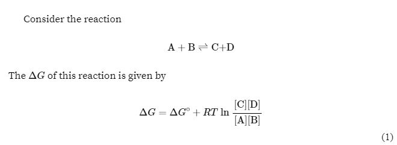

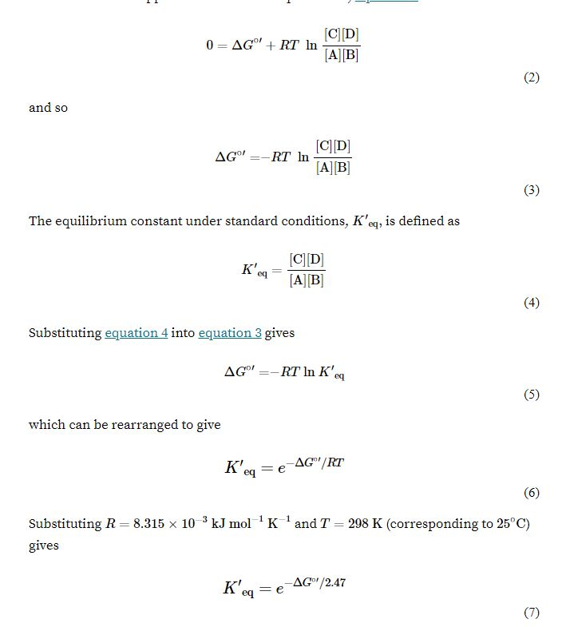

6.4 Enzymes and transition state

- enzymes reduce activation energy for transition states
  - active sites are 3d crevices with unique microstructures
  - substrates are bound to enzymes by weak interactions

#### Chapter 7

7.1 Kinetics

- reaction velocity changes with concentrations of substrate, rate equations have exponents of reactant coefficients

7.2 Michaelis-Menten

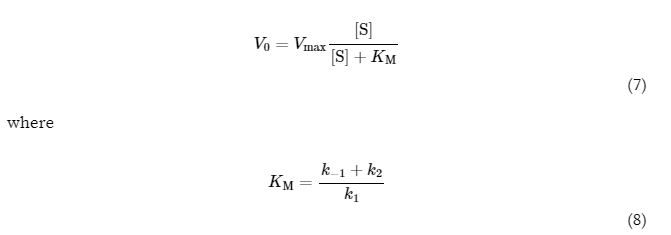

- $K_M$ is the substrate concentration when the reaction velocity is half the maximum

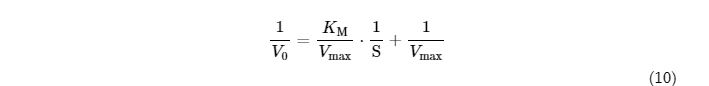

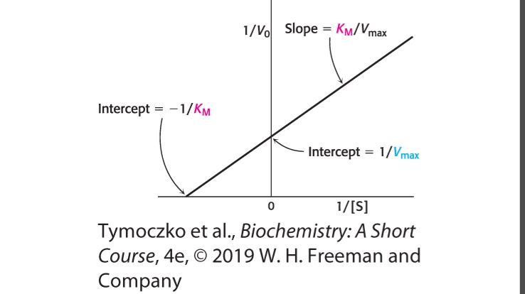

#### Week 4 Lectures

Ligand Bonding Proteins Video 1

- myoglobin is a globular protein, consists of multiple subunits and a prosthetic group
  - Heme: prosthetic group, tetrapyrrole rings; holds charged Iron within center of Heme

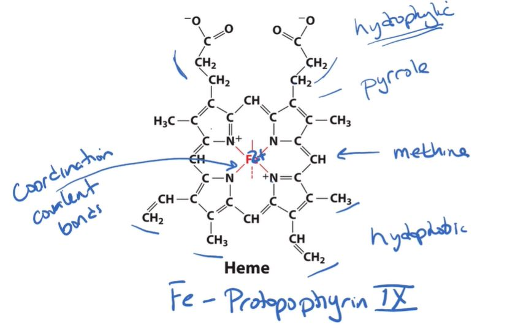

    - held in place by proximal histidine N residue; oxygen held in 6th Fe coordination is stabilized by distal histidine nitrogen group
      - distal histidine also protects free Iron from oxidation

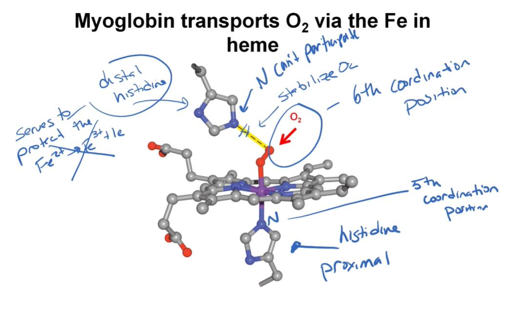

- dissociation constant: measures rate of protein-ligand complex dissociation

$$K_D = \frac{[P][L]}{[PL]}$$

- fractional saturation (Y): proportion of myoglobin bound to O$_2$; $Y=\frac{[MbO_2]}{[Mb]+[{MbO_2}]}$
- myoglobin binds in a hyperbolic trend $Y = \frac{pO_2}{K+ pO_2}$
- $K_D$ is inversely related to the affinity of the ligand for its protein
- myoglobin has a higher affinity for O$_2$ than hemoglobin
  - hemoglobin binding is sigmodial $\rightarrow$ allosteric
    - rate effect of ligand concentration (Hill coefficient) can range from 1 to the number of subunits in the protein
  - similar in secondary and tertiary structures
- oxygen binding reduces Iron electron cloud size, allows it to be pulled flatter into the porphyrin
  - causes conformational changes in Hb structure; T $\rightarrow$ R state, smaller central region

Allosteric Effectors Video 2

- oxygen binds cooperatively to hemoglobin (allosteric, function increases with binding)
  - high oxygen concentration in the lungs increases hemoglobin affinity
  - low oxygen concentration in lung tissue, myoglobin binds and transports it after hemoglobin drops it off
- binding curve of pure hemoglobin looks more like myoglobin; 2,3-BPG influences the affinity of hemoglobin for oxygen
  - fits into center hold of deoxyhemoglobin; stabilization of T state and creation of allosteric properties
- carbon dioxide and H$^+$ enhance oxygen release by hemoglobin; Bohr effect (negative effectors)
  - diffusion of carbon dioxide into red blood cells reaction of carbon dioxide and water to form carbonic acid; increases proton concentration as a result of cellular respiration
- hemoglobin has a lower affinity for oxygen at lower pH across all O$_2$ partial pressures; results in increased oxygen offloading
  - carbon dioxide also reduces hemoglobin binding affinity; reacts with terminal amino groups to form charged carbamate groups, stabilizes T state
  - result in oxygen acquisition the lungs and release in tissue
- HbA: normal adult hemoglobin, 2 $\alpha$ and 2 $\beta$ subunits
  - HbS: sickle hemoglobin, point mutation on $\beta$ chain; causes precipitation due to hemoglobin polymerization
  - deoxy T state has Phe 85, Leu 88, Val 6 exposed: creation of sticky site and hemoglobin aggregates
  - HbF: fetal hemoglobin, usually all converted to HbA
- carbon monoxide binds to a single heme site, and increases other subunit’s binding affinity (oxygen is no longer released into tissue)

Carbohydrates Video 3

- monosaccharides are aldehydes or ketones with two or more alcohol groups (D saccharides are biologicaly active, hydroxyl on right)
  - many isomeric forms of carbohydrates

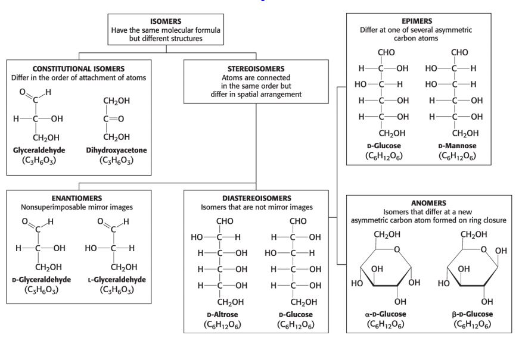

  - cyclic carbs can be $\alpha$ (C-1 hydroxyl down) or $\beta$ (C-1 hydroxyl up)
- fructose can be in either 5 or 6 member cyclic forms (furanose or pyranose)
- glucose can react with oxidizing agents when in open form (prevents cyclic binding)
- oligosaccharides contain monosaccharides linked by O-glycosidic bonds (anomeric carbon of glucose and hydroxyl group)
  - polymerization structure influences which carbs can be digested
- glycoproteins consist of proteins attached to carbohydrates
  - glyoprotein: protein is largest component; membrane functions
  - proteoglycan: protein is attached to glycosaminoglycan, mostly carbohydrate; strutural or lubricant role
    - glycosaminoglycans have large repeating disaccharide units
  - mucoprotein: mostly carbohydrate, often lubricants
- linkage is normally to nitrogen in asparagine R group, or oxygen in serine or threonine R groups

Lipids Video 4

- Fatty acids: carboxylate joined with hydrocarbon chain
  - referred to by number of carbons and double bonds present
  - Omega or Delta nomenclature can be used to convey position of double bonds (from ending or from starting carbons)
  - saturated fatty acids solidify easier, have high melting temperature
- triacylglycerol: energy storage molecule, holds onto fatty acid chains
- waxes: formed when long chain alcohol and fatty acid join with an ester bond
  - fats have unique aqueous configurations based on solubility
- types of membrane lipids:
  - phospholipids: contain 2 fatty acids, platform, phosphate, and an alcohol
    - platforms are usually glycerol or sphingosine
  - glycolipids are carb containing lipids, with carb on extracellular surface of cell membrane where they play a role in cellular interactions
  - steroids: built on tetracyclic platform: cholesterol maintains membrane fluidity and is a precursor to hormonal steroids

Clutch Protein Ligand

- ligand: any small substance that can reversibly bind with a larger biomolecule
- the higher the rate constant, the reaction is likely faster
  - ligands have rates of association and dissociation $k_a, k_d$ for forming PL and breaking PL

Clutch Ligand Equilibrium

- association and dissociation rate constants $(K_a, K_d)$
  - the greater the $K_a$, the stronger the affinity for ligand
  - $K_a$ has units of $M^{-1}$ and is the reciprocal of $K_d$; $K_a = \frac{[PL]}{[P][L]} = \frac{k_a}{k_d} = \frac{1}{K_d}$
- $K_d$ is more commonly used, and has a similar interpretation to $K_m$; both inversely represent binding affinity
  - $K_d = [L]$ allows half of the binding sites to be occupied

Clutch fractional saturation

- Y: fraction of occupied ligand binding sites
  - saturation curves plot $\theta$ against $[L]$, we can use this to find the $K_d$
    - $\theta = \frac{[L]}{[L]+K_d}$

Chapter 9

9.1 Hemoglobin displays cooperative behavior

- hemoglobin exhibits cooperative effect characteristic of allosteric enzymes; allows full saturation in the lungs and transport to tissue

9.2 Myoglobin and Hemoglobin bind oxygen in Heme groups

- both myoglobin and hemoglobin rely on prosthetic heme group to bind to oxygen; central Iron is stabilized by 4 charged nitrogens, as well as histidine residue;
  - the last Iron coordination site remains open to bind to oxygen; tightens Iron electron cloud to flatten porphyrin ring

9.3 Hemoglobin binds oxygen cooperatively

- heme consists of 2 $\alpha$ and 2 $\beta$ subunits, similar to those of myoglobin
  - oxygenation results in a T to R conversion, central pore is held tighter

9.4 An allosteric regulator determines the oxygen affinity of hemoglobin

- 2,3-BPG reduces hemoglobin oxygen affinity to increase delivery to tissues
  - fits in the central pore of T hemoglobin, leads to release of oxygen and T form stabilization

9.5 Protons and carbon dioxide promote the release of oxygen

- hydrogen ions and carbon dioxide, byproducts of metabolism, enhance oxygen release

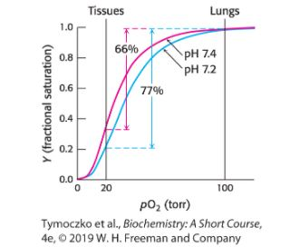

  - creation of stabilizing salt bridges and carbamate reduce oxygen affinity

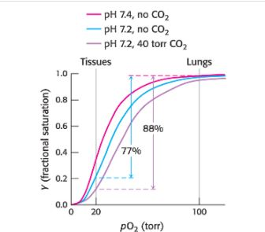

9.6 Heme subunit mutation can lead to disease

- point mutations decreases solubility of deoxygenated hemoglobin, results in a high concentration of deoxygenated Hb
  - sickles nearby cells by reducing oxygen concentration in narrow blood vessels

Chapter 10

10.1 Monosaccharides are the simplest carb

- aldehydes or ketones with at least two hydroxyl groups
  - can be a ketose or aldose (if they have a keto or aldehyde group)
- carbs occur in a large number of isomeric forms; chiral centers contribute diastereoisomers
- carbs often react to form cyclic forms, which can be alpha or beta form depending on orientation of hydroxyl bound to carbon 1
- glycosidic bonds:
  - O-glycosidic: bond between anomeric carbon of glucose and oxygen of alcohol
  - N-glycosidic: bond between anomeric carbon of glucose and nitrogen of amine

10.2 Monosaccharides are linked to form complex carbs

- oligosaccharides are built by linkage of two or more monosaccharides by O-glycosidic bonds
  - actual bond chemistry depends on type of ring configuration and carbon position
- glycogen and starch are storage forms of glucose
  - polysaccharides play important roles in energy and structure
  - glycogen is used for energy storage in animal cells; starch (amylopectin and amylose) are the storage form for plants
- cellulose is a structural carb, unbranched glucose joined by $\beta$-1,4 linkages instead of the $\alpha$-1,4 linkages
  - straight chain form can’t be digested by mammals (still improves digestion)

10.3 Carbs are attached to proteins to form glycoproteins

- sugars are attached to amide nitrogen in asparagine, or hydroxyl oxygen in serine or threonine (largely protein by weight)
- proteoglycans: more carb by weight, function as lubricants and structural components, mediate cellular adhesion
  - human blood groups are based on glycosylation patterns

Chapter 11 Lipids

11.1 Fatty Acids

- chains of hydrocarbons with terminal carboxylic acid groups
  - act as fuel and building blocks for membrane lipids
  - formal name is based on parent hydrocarbon name
  - fatty acids with one or more double bonds are unsaturated, no double bonds is saturated
  - n:m notation has n carbons with m double bonds
  - carbon atoms are numbered starting at carboxyl terminus (Delta system, but can be reversed for the w system)
  - unsaturated fats have lower melting points than saturated ones
    - chain interaction (van der Whaal) is made more difficult when chains aren’t straight
  - shorter chains also have lower melting points

#### Week 5 Lectures

U2W5V1

- higher protein membrane content than commonly portrayed (25% - 80%), spontaneous membrane formation is driven by hydrophobic effect
  - carb side chains of glycolipids are usually outward facing
  - integral and peripheral membrane proteins
- cholesterol disrupts straight chain bonding; can also form complexes with lipids and proteins (lipid raft to speed up chemical processes)
- proteins have been shown to diffuse across the membrane; lipids can diffuse laterally or transverse (fast vs slow)
  - phospholipids are usually asymmetrically distributed across the bilayer
- integral proteins cross the bilayer; peripheral proteins are somehow attached to a single side
  - bacteriorhodopsin: series of alpha helices spanning membrane (most common motif)
    - bilayers are generally very thin (10 nm, about 66 amino acid long alpha helices)
  - bacterial porin: beta strands form a central pore (transmembrane barrel), less selective transport
  - peripheral proteins can contribute to binding of signalling enzymes (prostaglandin requires a fatty acid to become activated)
- membrane transport processes
  - nonmediated transport: diffusion across a membrane, can be fast for hydrophobic or polar (fast or very slow respectively)
    - movement from higher to lower gradient, no energy input required
  - facilitated (passive) transport: diffusion of solutes is accelerated by transporter proteins (pores, channels, carriers)
  - active transport requires energy to transport molecules against their gradient
- uniport: one molecule moving
- symport: two different molecules moving in the same direction
- antiport: two differenet molecules moving in opposite directions
- channel vs pump
  - with vs against gradient
  - potassium channel selects against sodium: carbonyl interior forces potassium to peel away from hydration shell, sodium isn’t large enough to form bonds with carbonyls

U2W5V2

- we can use free energy calculations to determine if molecules will move across a bilayer
  - $\Delta G^o$ is 0 for diffusion across a semi-permeable membrane $\rightarrow \Delta G = R \ T \ ln(Q)$, where $Q = \frac{Final}{Initial}$
- membrane potential: associated change in free energy as charged species cross potential gradient ????????????????????????? need to review this
  $$\Delta G _t = RT ln(C_2/C_1) + Z F \Delta \Psi$$
  - most cells have more anions inside the cell, creates a voltage (charge buildup across bilayer)

U2W5V3

- refer to net change in free energy to determine if a symport or antiport transport process is spontaneous
- secondary transport: nonspontaneous transport mediated by an active transporter establishing a gradient
- sodium potassium antiporter: requires external energy, for every ATP used 3 sodium are pumped out and 2 potassium are pumped in (both against their concentration gradients)
  - hydrolysis of ATP has a large negative free energy change: spreading out of negative charges, increased entropy, more stable inorganic phosphate form due to resonance
  - chemical energy from energy is transferred into mechanical energy (phosphate drives a conformationsl change in the pump protein)
  - 1. ATP binds to the ATP binding site, allowing sodium to enter the pump
  - 2. phosphate remains bound to aspartate residue, ADP release causes pump to open outside
  - 3. Sodium is released and potassium enters the pump
  - 4. ATP binds and knocks off phosphate
  - 5. inside opens and potassium enters

#### Week 6 Lectures

U2W6V1

- primary messengers can generate intracellular secondary messenger, which can then activate a signal cascade until signal ceases
  - hormones: chemical messengers, cannot easily pass through membrane (except steroids)
  - photons: signalling proteins can pick up light via conformational changes
  - neurotransmitters: small molecule transmitting nerve signals
- transmembrane receptor protein changes conformation to transfer signal
  - 7 transmembrane-helix receptor: consists of 7 alpha helices, activates a G protein (GTP or GDP bound) when signaled; causes activation of an interior protein kinase
    - subunits separate from GDP, GTP replaces it; GTP subunit binds to adenylate cyclase to generate cyclic AMP and turn on kinase (phosphorylate another substrate)
    - Adenylate cyclase is turned off by phosphorylating GTP to GDP, which forces subunit reassociation and freeing from adenylate cyclase
    - cAMP also resets the kinase as it’s spontaneously converted back to AMP
    - as concentration of primary messenger decreases, it spontaneously dissociates and switches off the receptor

U2W6V2

- Dimeric membrane receptors that recruit protein kinases
  - quaternary structural change instead of tertiary drives mechanism
  - receptor dimerizes once signal factor binds; cross phosphorylation results in activation of kinase, enables further phosphorylation
- dimeric protein receptors that are protein kinases
  - single integral protein has both receptor and kinase function; receptor brings entire subunits together, phosphorylates and activates another signaling G protein

U2W6V3

- digestion: set of biochemical reactions to convert food into biologically useful building blocks
  - begins in mouth, food is chewed and mixed with saliva (water + mucoproteins, alpha amylase and ions)
  - stomach pump uses energy to create acidic environment, denatures consumed proteins
    - peptide backboen is more exposed, can be more easily hydrolysed into oligopeptides
  - stimulates reduction of acidic conditions by pancreas so other enzymes can enter; gallbladder releases bile to digest lipids
    - gastric and pancreatic enzymes hang out as zymogens until activated by proper conditions
  - digestion of proteins
    - oligopeptides are broken into amino acids, absorbed into intestinal cells and pushed through antiport into blood
  - monosaccharide digestion
    - Galactose + Glucose symport transport with sodium, Fructose uniport into intestinal cell; uniport into blood stream
  - lipid digestion
    - need to account for hydrophobicity; bile makes lipids more soluble through detergent activity
    - cholesterol as precursor for bile, use of fiber to reduce cholesterol levels
    - micelle formation, transport to intestinal cells and lymph systems

U2W6V4

- basic principles of energy manipulation
  - use of metabolic pathways to control energy flow
  - ATP is the energy currency of life, and is used to drive nonspontaneous processes forward
  - ATP can be formed by the oxidation of carbon fuels
  - a limited number of reaction types with common intermediates
  - metabolic pathways are highly regulated
  - enzymes are organized into large complexes
- catabolic pathways combuts carbon fuels to synthesize ATP or create ion gradients
- anabolic pathways use ATP to synthesize larger biomolecules
- exergonic ATP hydrolysis can be used to drive endergonic reactions
  - energy stored in high energy phosphate bonds; breaking of ATP results in
    - freeing of negative charge repulsion
    - resonance stabilization increases
    - increase in entropy
    - stabilization by hydration
- Phosphoryl-transfer potential: standard free energy of hydrolysis of a phosphate group (more negative is more prone to transfer/higher energy when transferred)
- exercise depends on ATP generation; creatine phosphate regenerates ATP from ADP, allowing for short bursts; longer stretches must use other metabolic pathways

U2W6V5

- recurring theme of activated carriers
  - carriers are kinetically stable in absence of specific catalysts
  - metabolism of activated groups is accomplished with few carriers
- ATP can be considered a carrier for phosphate groups, used to activate or tag many groups
- NAD$^+$ and NADP$^+$, differ in presence of phosphate group
  - differ in where they carry electrons
- many activated carriers are derived from vitamins (B vitamins serve as coenzymes)

Chapter 13 Signal Pathways

13.1 Signal Transduction Depends on Molecular Circuits

- all signal circuits contain
  - release of primary messenger
  - reception of primary messenger: membrane receptors transfer information into the cell using intra and extracellular domains; binding to ligand alters the structure of the receptor
  - relay of information by the second messenger: receptor changes lead to changes in second messenger concentrations
  - activation of effectors that directly alter the physiological response: activation of inhibition of tools controlling metabolism, gene activation, and nerve transmision
  - termination of the signal

13.2 Receptor Proteins Transmit Information into the cell

- seven transmembrane helix receptors
  - consists of 7 helices spanning the membrane
  - ligand binding causes a conformation change in 7TM receptors
  - G protein: coupled to ligand binding, transmits signal to interior of cell
    - unactivated GDP bound to inactive $\alpha$ and $\gamma$ subunits is replaced by active GTP by ligand binding
  - G proteins can bind to adenylate cyclase, increasing cAMP production
    - increased cAMP concentration can activate protein kinases
    - PKA (protein kinase A) consists of two regulatory and two catalytic subunits that are inactive in absence of cAMP; cAMP binding to regulatory subunits frees the catalytic subunits to perfom enzymatic phosphorylation
    - $\alpha$ subunits of G have GTPase activity, converting it into GDP and free phosphate; acts as a clock to reset the GDP-bound form after some time
  - ligand can also dissociate based on concentration (reversible binding)
  - phosphoinositide cascade: intracellular messengers made from cleavage of membrane protein into IP$_3$ and diacylglycerol; IP$_3$ causes a release of calcium ions into the cytoplasm, while Diacylglycerol + calcium activates a protein kinase

13.3 Some Receptors Dimerize in response to ligand binding

- receptors have a single membrane-spanning helix; ligand binds to two receptors to activate it
  - JAK2 receptors phosphorylate each other upon ligand binding, and are then free to phosphorylate other molecules
  - Ras is part of the small G protein family, which assists in almost all cell functions
    - cycle between active GTP and inactive GDP-bound forms as well

Chapter 14 Digestion

14.1 Digestion prepares large biomolecules

- proteins, fats, carbs are digested into their basic components by proteases, lipases, and carb digestive enzymes
- almost all digestive enzymes are secreted in inactive form (zymogen); activate d by proteolytic cleavage when signaled

14.2 Proteases digest proteins

- proteins are denatured in the stomach, then pepsin begins to break them into protein fragments
  - acidic environment is generated by gastric proton pumps
- small intestine releases secretin, which stimulates neutralizing sodium bicarbonate release
  - cholecystokinin is released by intestinal cells, which stimulates other digestive enzymes from the pancreas
  - oligiopeptides are broken into animo acids by peptidases attached to intestinal surface, which are then transported into intestinal cells

14.3 $\alpha$ Amylase digests carbs

- unique carbohydrates are digested by corresponding enzymes, until they become monomers
  - glucose and galactose are transported into intestinal cells with a symport channel, fructose diffuses through GLUT5 transporter; these then move through GLUT2 into the bloodstream

14.4 Lipid digestion depends on hydrophobicity

- lipids must be degraded to fatty acids for absorption
- lipids converted into emulsion in stomach, after which bile salts are added; pancreatic lipases produce fatty acids and mono acylglycerol, which are carried in micelles to be absorbed by intestinal cells
  - move into cells by FABP, then moved to smooth ER and release to lymph system and blood

Chapter 15 Metabolism

15.1 Energy is required for fundamental needs

- living organisms require free energy to
  - perform mechanical work in cellular movement
  - actively transport molecules
  - sythesize macromolecules

15.2 Metabolism has many interconnected reactions

- metabolism is a series of chemical reactions that converts a biomolecule in a defined fashion; can convert energy to useful forms, or require energy inputs to proceed (catabolic vs anabolic)
  - irreversible reactions of pathways are always distinct
- overall free energy change is the sum of changes for coupled reactions; thermodynamically unfavorable processes can be made favorable by coupling

15.3 ATP is the currency of free energy

- free energy is converted to ATP, which then drives anabolic processes
  - ATP is energy rich due to triphosphate unit; strong charge repulsions are freed when hydrolyzed to ADP and AMP
  - large phosphoryl-transfer potential of ATP is due to:
    - electrostatic repulsion
    - resonance stabilization of orthophosphate compared to bound phosphate
    - increase in entropy
    - products are stabilized by hydration

15.4 Oxidation is a source of cellular energy

- ATP is not a long-term storage form of energy (high ATP turnover, generated by catabolism)
  - carbon is oxidized to $\text{CO}_2$ and ATP is regenerated (electrons lost and gained, oxidation-reduction reactions); oxidation occurs one carbon at a time
- electrons are captured by NAD$^+$, and high phosphoryl tranfer-potential drives ATP regeneration (trapped as high-phosphoryl transfer potential intermediate)

15.5 Metabolic pathways have recurring motifs

- activated carriers of electrons for oxidation
  - electrons are transferred between carriers before oxidizing O$_2$
  - NAD$^+$ is a major electron carrier in oxidation of fuel; nicotinamide ring is reduced to NADH
- activated carriers of electrons of the synthesis of biomolecules
  - reductive biosynthesis: reduction of precursors in anabolism
  - NADPH is used for reductive biosynthesis; NADH for ATP generation
- activated carrier of two-carbon fragments
  - CoA: carries acyl groups, derived from pantothenate; high acetyl group transfer potential
- all are kinetically stable in absence of catalysts, enable control of free energy generation; many active group interchanges are done by small set of carriers
- many activated carriers are derived from vitamins: niacin, riboflavin, pantothenate, other B vitamins
  - other vitamins serve non-coenzyme functions and are needed for proper function

15.6 Metabolic processes are regulated in 3 ways

- control of amount of enzymes: adjusted by rate of transcription of genes encoding them
- their catalytic activities: allosteric control, feedback inhibition, reversible covalent modification
  - hormones coordinate metabolic relations, often through reversible modification of enzymes
  - energy charge: measure of energy status of the cell $\text{energy charge} = \frac{\text{[ATP] + 1/2[ADP]}}{\text{[ATP]+[ADP]+[AMP]}}$
    - high energy charge inhibits catabolic pathways, stimulates anabolism; usually buffered near $0.85$
    - can also consider the phosphorylation potential $= \frac{\text{[ATP]}}{\text{[ATP]+[P}_i]}$
- accessibility of substrates
  - regulation and flexibility enhanced by compartmentalization (separate opposed reactions)